# ARMA Analysis with Python

###### By Rohit Pardasani

```python
import statsmodels.tsa.stattools as ts
import numpy as np
import pandas as pd
```

Let's say we come across a time series that we want to model as ARMA. How do we start ?

1. Get ACF and PACF plots
2. Try to guess the order of AR and MA through PACF and ACF plots respectively
3. We may not be complete sure about order, so we try to fit all possibilities and calculate fitness of each model using with respect to chosen metrics
4. The one with better fit (say based on AIC) is choosen
5. We can sacrifice a marginally better fit in favour of parsimony

### Let's synthesize a ARMA(p,q) process

$X_t = Z_t + 0.7Z_{t-1} + 0.5Z_{t-2}+ 0.6X_{t-1}$  
Thus, p=1 and q=2 for this process.

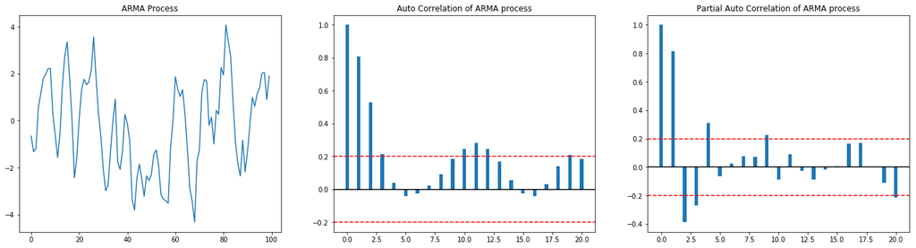

```python
import matplotlib.pyplot as plt
from statsmodels.tsa import arima_process
ma_params = [1,0.7,0.5]
ar_params = [1,-0.6]
x = arima_process.arma_generate_sample(ar=ar_params,ma=ma_params,nsample=100)
plt.figure(figsize=(24,6))
plt.subplot(1,3,1)
plt.title("ARMA Process")
plt.plot(x)

plt.subplot(1,3,2)
acorf_x = ts.acf(x,fft=False,adjusted=False,nlags=20)
plt.bar(x=np.arange(len(acorf_x)),height=acorf_x,width=0.3)
plt.axhline(y=0,color='black')
plt.axhline(y=0.2,color='red',linestyle='--')
plt.axhline(y=-0.2,color='red',linestyle='--')
plt.title("Auto Correlation of ARMA process")

plt.subplot(1,3,3)
apcorf_x = ts.pacf(x,nlags=20)
plt.bar(x=np.arange(len(apcorf_x)),height=apcorf_x,width=0.3)
plt.axhline(y=0,color='black')
plt.axhline(y=0.2,color='red',linestyle='--')
plt.axhline(y=-0.2,color='red',linestyle='--')
plt.title("Partial Auto Correlation of ARMA process")

#plt.plot(x)
plt.show()
```

ACF indicates that MA process could be of order of 3 (i.e. q=3)  
PACF indicates that AR process could be of order of 2 (i.e. p=2)  
So, let's try p=(0,1,2) and q=(0,1,2,3)

```python
from statsmodels.tsa.arima.model import ARIMA
models = []
results = []
orders = []
for p in range(3):
    for q in range(4):
        mod = ARIMA(endog=x, order=(p,0,q))
        res = mod.fit()
        models.append(mod)
        results.append(res)
        orders.append((p,q))
        print('Order p=%d,q=%d: AIC : %f , Parameters : p = %s q = %s"'%(p,q,np.round(res.aic,4),str(res.polynomial_ar),str(res.polynomial_ma)))
```

```
Order p=0,q=0: AIC : 421.358500 , Parameters : p = [1.] q = [1.]"
Order p=0,q=1: AIC : 356.664200 , Parameters : p = [1.] q = [1.         0.64748098]"
Order p=0,q=2: AIC : 303.639100 , Parameters : p = [1.] q = [1.         1.06399035 0.67760455]"
Order p=0,q=3: AIC : 299.285500 , Parameters : p = [1.] q = [1.         1.00288025 0.87794024 0.33046582]"
Order p=1,q=0: AIC : 315.725800 , Parameters : p = [ 1.         -0.81114066] q = [1.]"
Order p=1,q=1: AIC : 309.227000 , Parameters : p = [ 1.        -0.7417095] q = [1.         0.25483953]"
Order p=1,q=2: AIC : 293.519200 , Parameters : p = [ 1.         -0.55630743] q = [1.         0.5461306  0.45566991]"
Order p=1,q=3: AIC : 295.372000 , Parameters : p = [ 1.         -0.50750145] q = [1.         0.59279078 0.52286943 0.06350296]"
Order p=2,q=0: AIC : 302.175200 , Parameters : p = [ 1.         -1.12188274  0.37914329] q = [1.]"
Order p=2,q=1: AIC : 302.053900 , Parameters : p = [ 1.         -1.33045079  0.55321215] q = [ 1.         -0.23875462]"
Order p=2,q=2: AIC : 294.888900 , Parameters : p = [ 1.         -0.7859093   0.21689918] q = [1.         0.32075627 0.44407777]"
Order p=2,q=3: AIC : 296.635700 , Parameters : p = [ 1.         -1.04700149  0.35520865] q = [ 1.          0.06088008  0.29130568 -0.13989278]"
```

We explored 12 models  
By parsimony prinicple and AIC value it seems reasonable to choose p=1 and q=2, which is actually the model that was used for simulation.

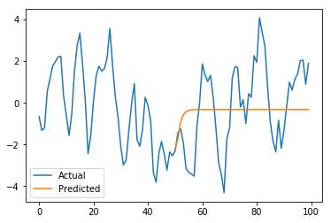

```python
xTrain = x[0:50]
xTest = x[50:100]
mod = ARIMA(endog=xTrain, order=(1,0,2))
res = mod.fit()
prediction = res.forecast(steps=50)
t = np.arange(len(x))
plt.plot(t,x,label='Actual')
plt.plot(t[50:100],prediction,label='Predicted')
plt.legend()
plt.show()
```

Model has failed to make a good long term prediction.These models are generally good for one step forecast. Let's try that.

```
Test RMSE: 1.065
```

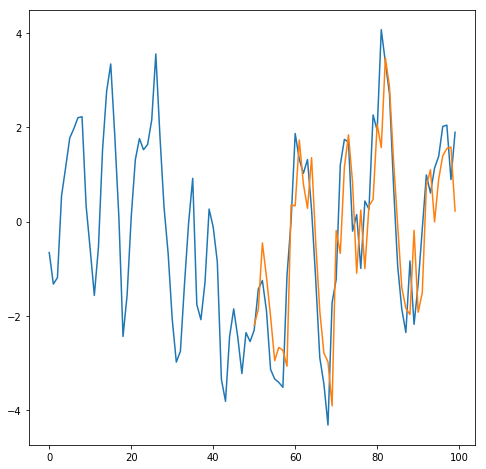

```python
from sklearn.metrics import mean_squared_error
from math import sqrt
history = [val for val in xTrain]
predictions = list()
# walk-forward validation
plt.figure(figsize=(8,8))
for ind in range(len(xTest)):
    model = ARIMA(history, order=(1,0,2))
    model_fit = model.fit()
    output = model_fit.forecast()
    yhat = output[0]
    predictions.append(yhat)
    obs = xTest[ind]
    history.append(obs)
    #print('predicted=%f, expected=%f' % (yhat, obs))
# evaluate forecasts
rmse = sqrt(mean_squared_error(xTest, predictions))
print('Test RMSE: %.3f' % rmse)
# plot forecasts against actual outcomes
plt.plot(t,x,label='Actual')
plt.plot(t[50:100],predictions,label='Predicted')
plt.show()
```

Somewhat better, but we are just making one step prediction.

What happens if we append history from prediction instead of actual observation ?

```
Test RMSE: 1.953
```

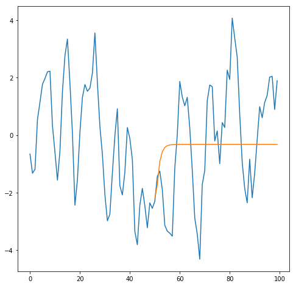

```python
from sklearn.metrics import mean_squared_error
from math import sqrt
history = [val for val in xTrain]
predictions = list()
# walk-forward validation
plt.figure(figsize=(8,8))
for ind in range(len(xTest)):
    model = ARIMA(history, order=(1,0,2))
    model_fit = model.fit()
    output = model_fit.forecast()
    yhat = output[0]
    predictions.append(yhat)
    obs = xTest[ind]
    history.append(yhat)
    #print('predicted=%f, expected=%f' % (yhat, obs))
# evaluate forecasts
rmse = sqrt(mean_squared_error(xTest, predictions))
print('Test RMSE: %.3f' % rmse)
# plot forecasts against actual outcomes
plt.plot(t,x,label='Actual')
plt.plot(t[50:100],predictions,label='Predicted')
plt.show()
```

Still doesn't work !!! ARIMA models are good for short term prediction and can't be used for long term prediction.

Are we doing better than just replicating previous value ?

```
Test RMSE: 1.177
```

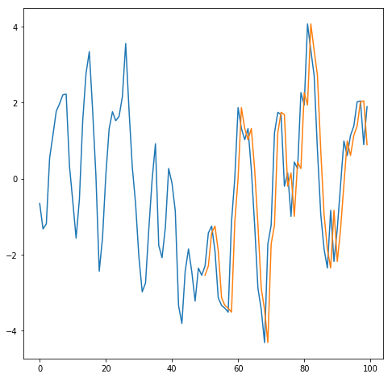

```python
from sklearn.metrics import mean_squared_error
from math import sqrt
history = [val for val in xTrain]
predictions = list()
# walk-forward validation
plt.figure(figsize=(8,8))
for ind in range(len(xTest)):
    predictions.append(history[-1])
    obs = xTest[ind]
    history.append(obs)
    #print('predicted=%f, expected=%f' % (yhat, obs))
# evaluate forecasts
rmse = sqrt(mean_squared_error(xTest, predictions))
print('Test RMSE: %.3f' % rmse)
# plot forecasts against actual outcomes
plt.plot(t,x,label='Actual')
plt.plot(t[50:100],predictions,label='Predicted')
plt.show()
```

Yes !!! We are doing slightly better by having ARIMA model in place, rather than just saying that last value is predicted value.